# Report on a pre-test of the TVJ-task

Michael

3/17/2019

20 participants were drafted on Prolific to complete a truth-value judgement task. Each participant was paid 1.20 pounds for compensation. The average time spent on the whole experiment (including reading instructions, and completing the post-experiment survey) was 3.96 minutes.

The experiment can be examined [here](https://michael-franke.github.io/misleading_with_underinfo/experiments/02_TVJ_pretest/index.html). The task consisted of 60 sentences presented completely at random from the following data set:

```
##      condition trigger                                 question
## 1      bizarre     all               All birds have telephones.
## 2      bizarre     all                    All chairs tell time.
## 3      bizarre     all                All couches have windows.
## 4      bizarre     all                  All crayons have noses.
## 5      bizarre     all                        All garages sing.
## 6      bizarre    most                  Most chairs are hungry.
## 7      bizarre    most             Most elephants have glasses.
## 8      bizarre    most             Most motorcycles like music.
## 9      bizarre    most                 Most sofas are friendly.
## 10     bizarre    most                Most tigers are literate.
## 11     bizarre  number          A week consists of five people.
## 12     bizarre  number               Forests last three nights.
## 13     bizarre  number                  Guitars have four legs.
## 14     bizarre  number              The earth owns seven books.
```

[output cut: 46 more lines]

Let’s first check whether anyone left any important comments, which appears to be not the case:

```r
d %>% pull(comments) %>% unique()
```

```
## [1] "I wasn't sure how to answer some questions for example if you asked most 'monkeys are mammals', that could be true or false in that monkeys are mammals which would make it 'true' but surely ALL monkeys are mammals so the question could be considered 'false'.  I'm probably overthinking this!!…
## [2] NA
## [3] "N/A"
## [4] "I understand that the sentences were probably randomly generated, however some of the sentences were worded quite poorly and did cause quite a bit of confusion when thinking  about whether they were true or false!"
```

The mean rate of “TRUE” judgements for each condition is:

```r
d_summary = d %>% group_by(trigger, condition, question) %>%
  summarize(mean_true = mean(response)) %>% arrange(condition)
d_summary %>% print.data.frame
```

```
##    trigger   condition                                 question mean_true
## 1      all     bizarre               All birds have telephones.      0.00
## 2      all     bizarre                    All chairs tell time.      0.00
## 3      all     bizarre                All couches have windows.      0.00
## 4      all     bizarre                  All crayons have noses.      0.00
## 5      all     bizarre                        All garages sing.      0.05
## 6     most     bizarre                  Most chairs are hungry.      0.00
## 7     most     bizarre             Most elephants have glasses.      0.00
## 8     most     bizarre             Most motorcycles like music.      0.00
## 9     most     bizarre                 Most sofas are friendly.      0.20
## 10    most     bizarre                Most tigers are literate.      0.05
## 11  number     bizarre          A week consists of five people.      0.00
## 12  number     bizarre               Forests last three nights.      0.05
## 13  number     bizarre                  Guitars have four legs.      0.05
## 14  number     bizarre              The earth owns seven books.      0.05
```

[output cut: 46 more lines]

Averaging over sentence material for each trigger-condition pair we get the following mean TRUE judgement ratings:

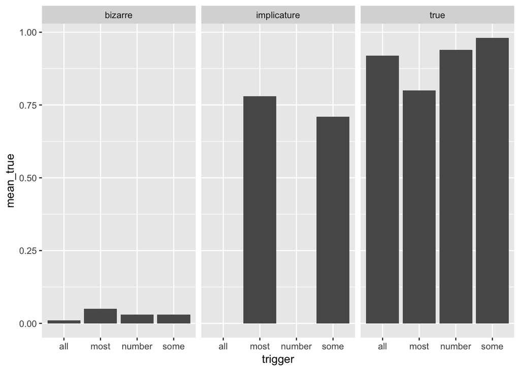

```r
d_summary %>% group_by(condition, trigger) %>%
  summarize(mean_true = mean(mean_true)) %>%
  ggplot(aes(x = trigger, y = mean_true)) +
  geom_bar(stat = "identity", position = "dodge") +
  facet_grid(~condition)
```

We see that the ‘bizarre’ control sentences are rated as false (usually) and that the ‘true’ controls receive rather high rates of ‘true’ judgements. However, the latter are not at ceiling and, most importantly: **the amount of ‘true’ endorsements for /most/ and /some/ in the implicatures condition is very high**. In contrast, as expected, sentences with /number/ words in the implicature condition are judged false. (But notice that these also have a slightly different sentences structure, perhaps suggesting a different information structure; we should not make a big deal of comparing /number/ on the one hand to /most/ & /some/ on the other hand in the implicature condition.)

```r
d_summary_id = d %>% group_by(submission_id, trigger, condition) %>%
  summarize(mean_true = mean(response)) %>% arrange(submission_id) %>%
  filter(condition == "implicature")
```

Finally, it is also interesting to see how individual participants behaved when confronted with implicature-items. The following looks at the mean ‘true’ judgements for /some/ and /most/ sentences in the implicature condition, for each participant individual. The histogram shows the distribution of each participant’s mean acceptance rate of the implicature sentences (excluding /number/ because everybody judged these ‘false’ anyway.)

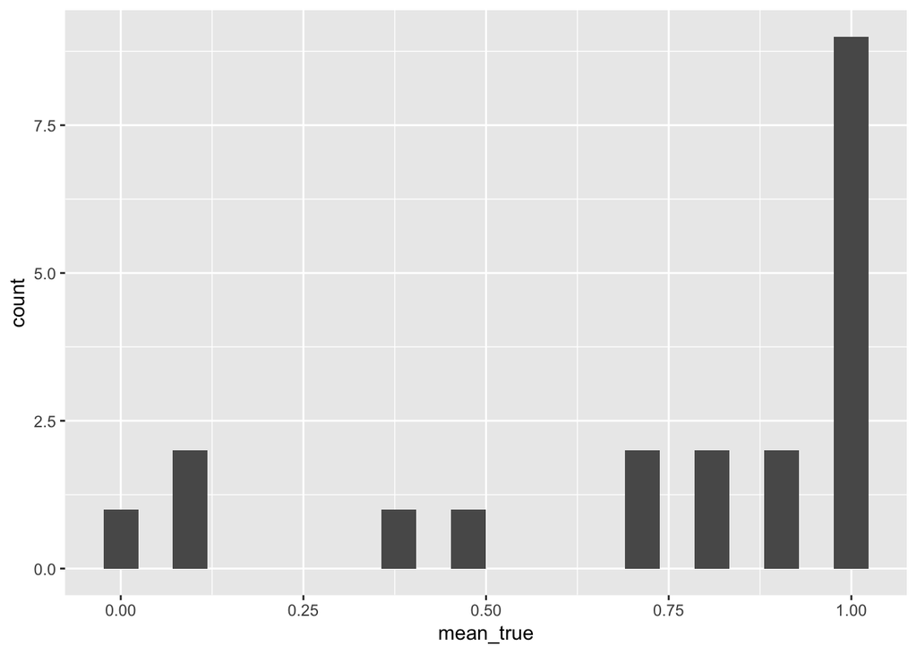

```r
d %>% group_by(submission_id, trigger, condition) %>%
  summarize(mean_true = mean(response)) %>% arrange(submission_id) %>%
  filter(condition == "implicature", trigger != "number") %>%
  group_by(submission_id) %>%
  summarize(mean_true = mean(mean_true)) %>%
  ggplot(aes(x = mean_true)) + geom_histogram(bins = 22)
```

We see that 9 out of 20 participants endorsed all occurrences of sentences with a false scalar implicature as ‘true’. 15 out of 20 participants endorsed them as ‘true’ with a rate of at least 7 out of 10. (Remember that each participant saw 10 items in the implicature condition, 5 with /some/ and 5 with /most/.)

If we split this up further into the mean judgements for /some/ vs /most/, the picture is:

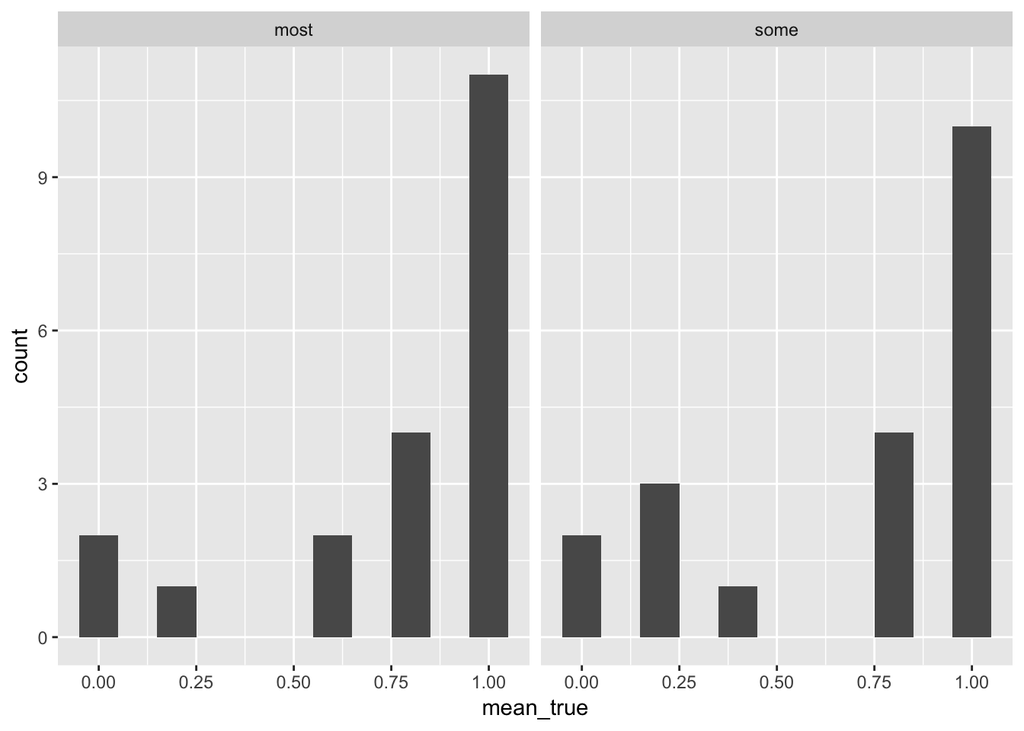

```r
d %>% group_by(submission_id, trigger, condition) %>%
  summarize(mean_true = mean(response)) %>% arrange(submission_id) %>%
  filter(condition == "implicature", trigger != "number") %>%
  group_by(submission_id, trigger) %>%
  summarize(mean_true = mean(mean_true)) %>%
  ggplot(aes(x = mean_true)) + geom_histogram(bins = 11) +
  facet_grid(.~trigger)
```

Finally, taking together the individual averages of ‘true’ judgements for /most/ and /some/, the 2D space in which participants reside with their answer profile looks like this:

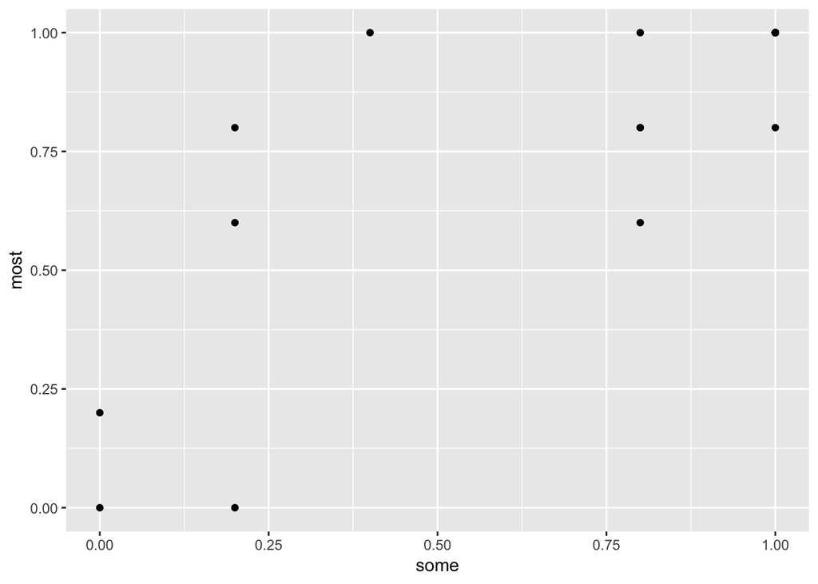

```r
d %>% group_by(submission_id, trigger, condition) %>%
  summarize(mean_true = mean(response)) %>% arrange(submission_id) %>%
  filter(condition == "implicature", trigger != "number") %>%
  group_by(submission_id, trigger) %>%
  summarize(mean_true = mean(mean_true)) %>%
  spread(key = trigger, value = mean_true)  %>%
  ggplot(aes(x = some, y = most)) +
  geom_point()
```

Although this data set is way too sparse, speculating wildly, it may appear as if there are three types of respondents:

1. those who judge /some/ and /most/ implicature-triggering sentences true
2. those who judge /most/ implicature-triggering sentences true, but /some/-sentences false
3. those who judge /some/ and /most/ implicature-triggering sentences false